# Coding Session 1: Coding, Stats, and R Basics

### Challenge 5

Use the faceted scatterplot to determine what classes of cars have the best highway mpg. What can we say about the engine sizes of those cars?

Now, try to answer the same question with the last scatterplot made (with color but without faceting). (*It should be a harder question to answer…*)

### Some additional examples

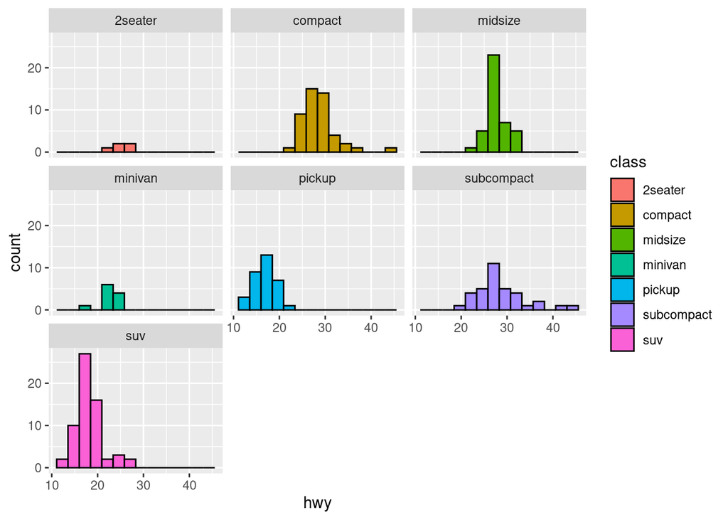

```r
ggplot(mpg) + geom_histogram(aes(x = hwy, fill = class), color = "black", bins = 14) + facet_wrap(~class)
```

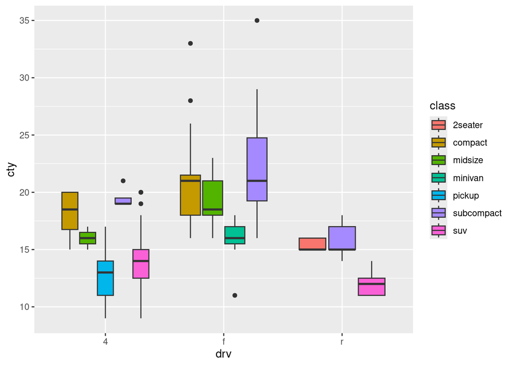

```r
# This is a good proof of concept, but produces some boxplots with too small
#   of sample sizes to get a good summary of.
ggplot(mpg) + geom_boxplot(aes(y = cty, x = drv, fill = class))
```

## 3.5 Correlation

The **correlation** is a summary statistic between two numeric variables is a number between $-1$ and $1$ that says how much one linearly affects the other (*meaning if you tried to draw a line to “fit” the data*).

```r
cor(mpg$hwy, mpg$cty)
```

```
## [1] 0.9559159
```

Some rules of thumb can be

- If correlation is greater than 0.7, the data is strongly correlated. If the $x$ variable increases, we expect the $y$ variable to increase as well.
- If correlation is between 0.3 and 0.5. If the $x$ variable increases, the $y$ variable tends to increase *(but less likely to do so than in the strong case)*
- If the correlation is between 0 and 0.3, the data is hardly correlated. It means that as $x$ increases, it’s tough to expect $y$ to increase as well.

For negative values, we switch one of “increase” to decrease. For example, if the correlation is -0.8, we would say “as $x$ increases, we expect $y$ to decrease.”

### Challenge 6

1. Go back and review the scatterplot of highway mpg and engine size (`displ`) (use the version with no color or faceting). What tends to happen to highway mpg for larger engine cars? Smaller?
2. Now, compute their correlation. Is its value consistent with the scatterplot?

### Challenge 7

Think of two scenarios:

1. Two variables that are correlated with one another, and there **is** a causal relationship.
2. Two variables that are correlated with one another, and there **is not** a causal relationship. *(This happens in the shark attack example. Think of a new example.)*

### Scatterplots with lines of best fit

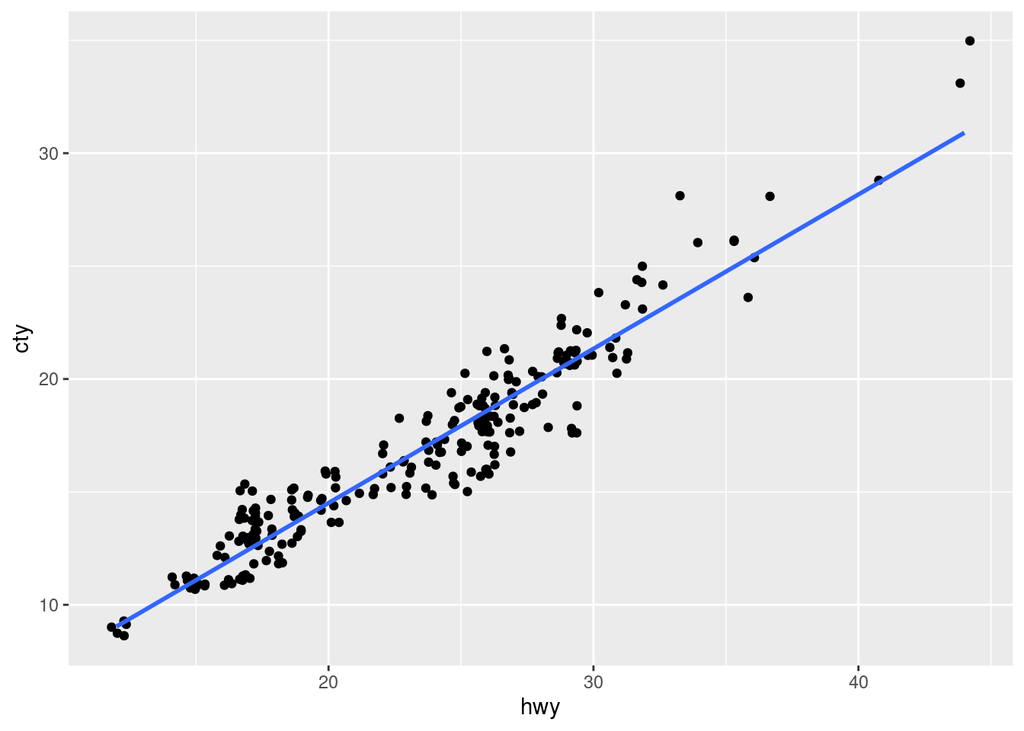

```r
ggplot(mpg, aes(x=hwy, y = cty)) +
  geom_jitter() +
  geom_smooth(method = lm, se = FALSE)
```

Lines of best fit can be misleading *(and other methods should be used)* when there is not a linear relationship:

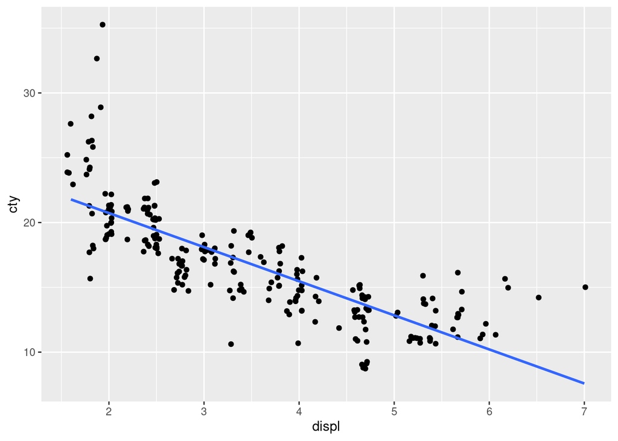

```r
ggplot(mpg, aes(x=displ, y = cty)) +
  geom_jitter() +
  geom_smooth(method = lm, se = FALSE)
```

This line is “pretty accurate” but only works for certain parts of the graph. Notice that it is inappropriate for very large and very small engine sizes.